# Heroin Usage and Annual Income

Julianne Zech

5/31/2019

## Introduction

In this exercise, I will seek to answer the following question: how do the annual family incomes of people who have used heroin differ from those who have never used heroin? To address this question, I will use data from the [2014 National Survey on Drug Use and Health](https://www.datafiles.samhsa.gov/study/national-survey-drug-use-and-health-nsduh-2014-nid13618), which is conducted annually by the Substance Abuse and Mental Health Services Administration (SAMHSA), an agency in the U.S. Department of Health and Human Services (DHHS). I will create three distinct displays to address my question of interest and provide an analysis of results and a final conclusion.

Survey respondents are members of the U.S. civilian, non-institutional population aged 12 or older. The survey tracks trends in substance use and mental illness and assesses the consequences of these conditions by examining mental and/or substance use disorders and treatment. Respondents were also asked about personal and family income sources and amounts, health care access and coverage, illegal activities and arrest record, problems resulting from the use of drugs, perceptions of risks, and needle-sharing. According to the [Center for Disease Control (CDC)](https://www.cdc.gov/nchs/data/nvsr/nvsr67/nvsr67_09-508.pdf), heroin was the drug responsible for 10,882 overdose deaths in the U.S. in 2014, the most of any drug that year. Its deadly effects are clear, but I am interested in the correlation of its usage, past and present, with income.

In the analysis below, I will separate survey respondents into two distinct groups. The “used” group consists of the 942 individuals who answered “Yes” to the question “Have you ever, even once, used heroin?” The “never” group consists of the 54,296 individuals who answered “No” to the same question. There were 28 individuals who answered “Don’t Know” and 5 who refused. They are not represented in either group.

## Loading the Data

First, I’ll load essential packages and the data set. For convenience, I’ll rename the data to something more intuitive.

```r
library(tidyverse)
library(forcats)

load("36361-0001-Data.rda")
full_data <- da36361.0001
remove(da36361.0001)
```

## Data Manipulation

I need to subset my data into two smaller data sets, one for each of my groups. Next, I will create a user status variable to idnetify which records belonging to each group after I combine the two data sets. I’ll also shorten the lengthy labels identifying income groups to make the graphs a bit sleeker.

```r
# remove any individuls who have missing values for HEREVER and/or INCOME
full_data <- filter(full_data, !is.na(HEREVER),!is.na(INCOME))

# subset data into two groups
used <- filter(full_data, HEREVER == "(1) Yes")
never <- filter(full_data, HEREVER == "(2) No")

# remove full_data object
remove(full_data)

# drop unneeded variables from used and never data sets
used <- select(used, INCOME)
never <- select(never, INCOME)

# create user status variable for each group
used$user_status <- "Used"
never$user_status <- "Never Used"

# change income survey labels for each group to something more readable
used <- mutate(used, INCOME = fct_recode(INCOME, "< $20,000" = "(1) Less than $20,000", "$20,000 - $49,999" = "(2) $20,000 - $49,999", "$50,000 - $74,999" = "(3) $50,000 - $74,999", ">= $75,000" = "(4) $75,000 or More"))
never <- mutate(never, INCOME = fct_recode(INCOME, "< $20,000" = "(1) Less than $20,000", "$20,000 - $49,999" = "(2) $20,000 - $49,999", "$50,000 - $74,999" = "(3) $50,000 - $74,999", ">= $75,000" = "(4) $75,000 or More"))

# combine the two groups into one data set
combined_data <- rbind(used, never)
```

## Side-by-Side Dot Plot

My first display will feature side-by-side dot plots of the relative frequency of belonging to each income group for people who have used heroin and those who have not. In the code shown below, you might notice that I’ve broken up the creation of each graph into several steps. I could have created them each in one line, but I wanted to make each step clear.

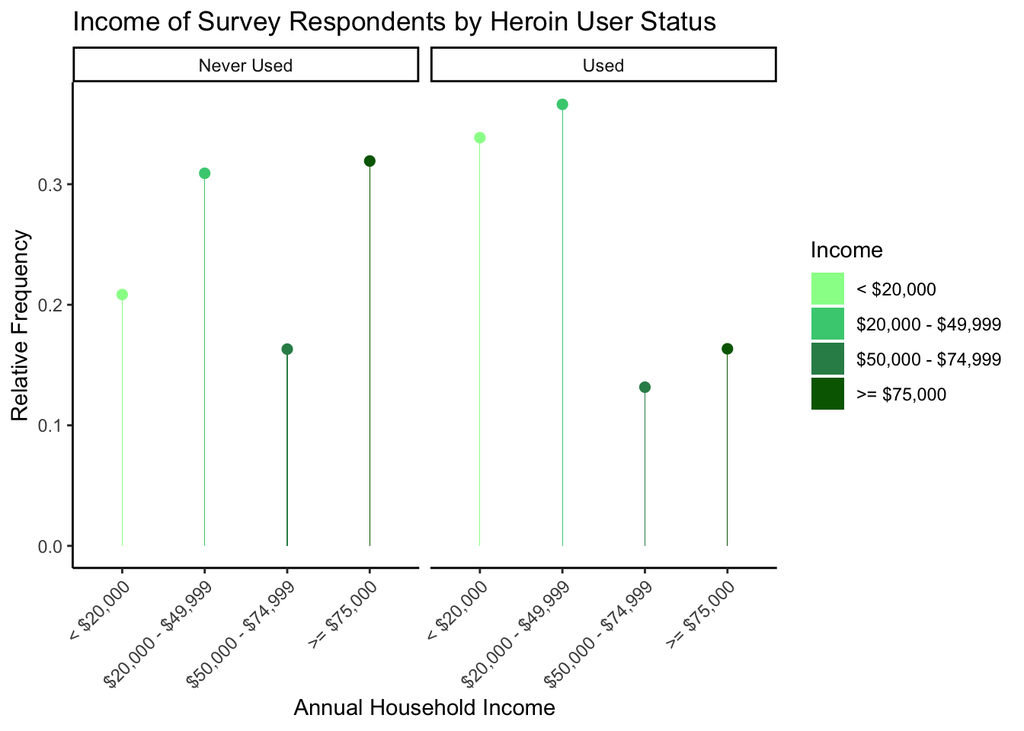

```r
# create base graphs
dotplot <- ggplot(combined_data) + geom_bar(aes(x=INCOME,fill=INCOME,  y = (..count..)/tapply(..count..,..PANEL..,sum)[..PANEL..]), width=0.01) + geom_point(aes(x=INCOME, y = (..count..)/tapply(..count..,..PANEL..,sum)[..PANEL..], color=INCOME), stat="count",size=2, show.legend=F)

# add a main title and axis titles, a background theme, and rotate bar labels so they don't overlap
dotplot <- dotplot + labs(title="Income of Survey Respondents by Heroin User Status", x="Annual Household Income", y="Relative Frequency", fill="Income") + theme_classic() + theme(axis.text.x = element_text(angle = 45, hjust = 1))

# add colors
dotplot <- dotplot + scale_fill_manual(values=c("palegreen", "seagreen3", "seagreen4", "darkgreen")) + scale_color_manual(values=c("palegreen", "seagreen3", "seagreen4", "darkgreen"))

# facet by user status
dotplot <- dotplot + facet_wrap("user_status")

# show the final graph
dotplot
```

## Side-by-Side Bar Chart

My next visualization is a side-by-side barplot that uses a “dodge” position adjustment instead of the faceting approach used above. This way, the bars for each user status appear next to one another for each respective income category. To accomplish this effectively, I need to create summary data for each user status group to see the relative frequency of income dependent on user status, not the relative frequency of each combination of income and user status. Creating the summary data requires computing the sum (the denominator of our relative frequency fraction) on a per panel/facet basis.

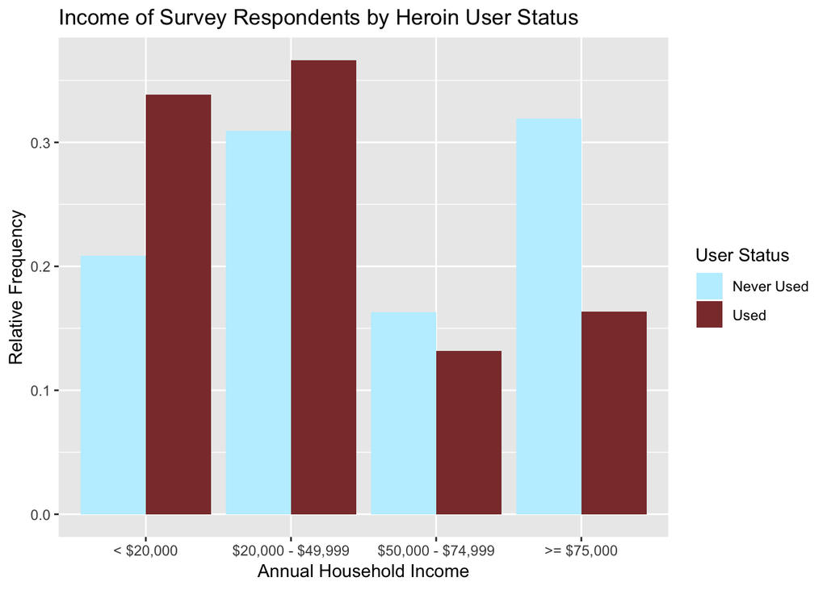

```r
# get counts of income distribution for "never" group
summary_data_never <- summarize(group_by(never, INCOME, user_status), count=n())

# compute relative frequencies of income distribution for "never" group
summary_data_never$percent <- summary_data_never$count/sum(summary_data_never$count)

# get counts of income distribution for "used" group
summary_data_used <- summarize(group_by(used, INCOME, user_status), count=n())

# compute relative frequencies of income distribution for "used" group
summary_data_used$percent <- summary_data_used$count/sum(summary_data_used$count)

# combine the summary data sets
summary_data <- rbind(summary_data_never, summary_data_used)

# create base bar chart with dodge position adjustment
barchart <- ggplot(summary_data) + geom_bar(aes(x=INCOME, fill=user_status, y=percent),
                                            position="dodge", stat="identity")

# add colors, titles, and labels
barchart <- barchart + scale_fill_manual(values=c("lightblue1", "indianred4")) +
  labs(title="Income of Survey Respondents by Heroin User Status", x="Annual Household Income",
       y="Relative Frequency", fill="User Status")

# show final graph
barchart
```

## Stacked Bar Charts

The last display is a stacked bar chart that shows the conditional distribution of income given the value of user status.

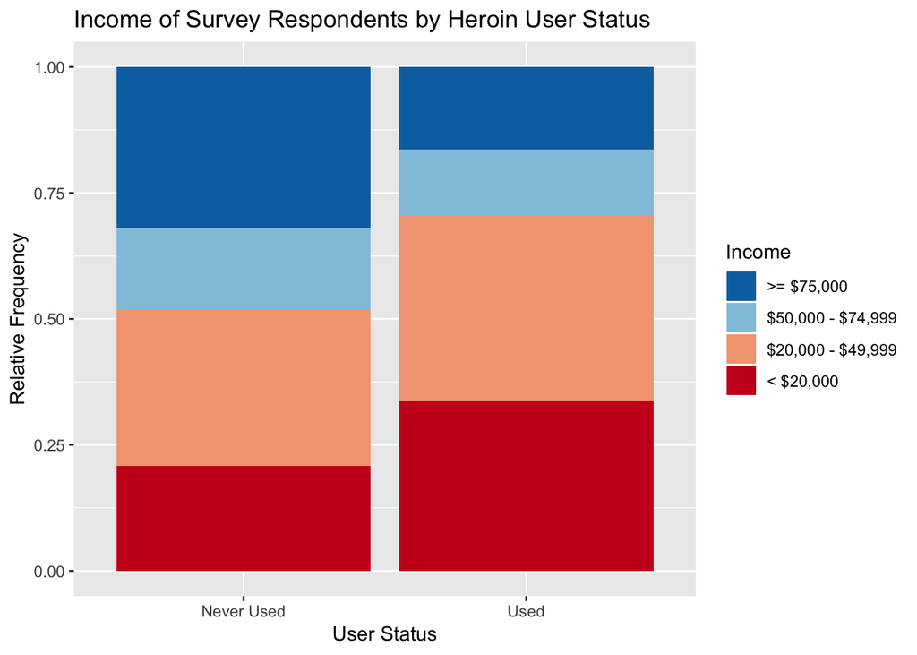

```r
# create base graph, reversing order of the levels so higher incomes appear at the top of the graph
stacked <- ggplot(mutate(combined_data, INCOME = fct_rev(INCOME))) + geom_bar(aes(x=user_status,fill=INCOME),
                                                                              position="fill")

# add colors, titles, and labels
stacked <- stacked + scale_fill_brewer(palette="RdBu", direction = -1) +
  labs(title="Income of Survey Respondents by Heroin User Status",
       x="User Status", y="Relative Frequency", fill="Income")

# show final graph
stacked
```

## Numerical Verification

Let’s look at the numerical data to verify the accuracy of my displays. The summary_data table below shows the number of respondents who gave each possible combination of responses to the two variables. With these numbers in hand, we can manually calculate the correct size for the geometric objects and compare them to the graphs. The count column reminds us of the large difference in sample sizes between the two groups. The numbers the percent column,however, reinforce the pictures shown by the graphs. We can easily check that the dots are in the right positions and the bars are the correct length.

```r
summary_data
```

```
## # A tibble: 8 x 4
## # Groups:   INCOME [4]
##   INCOME            user_status count percent
##   <fct>             <chr>       <int>   <dbl>
## 1 < $20,000         Never Used  11319   0.208
## 2 $20,000 - $49,999 Never Used  16781   0.309
## 3 $50,000 - $74,999 Never Used   8862   0.163
## 4 >= $75,000        Never Used  17334   0.319
## 5 < $20,000         Used          319   0.339
## 6 $20,000 - $49,999 Used          345   0.366
## 7 $50,000 - $74,999 Used          124   0.132
## 8 >= $75,000        Used          154   0.163
```

## Results

From the graphs, we can see that respondents who have never used heroin were more likely to have a higher income than respondents who had used heroin. A higher percentage of the respondents who have used heroin belong to the lowest two income categories than their counterparts who have never used heroin. 31.9% of respondents who have never used heroin have an annual family income $75,000 or above, while only 16.3% of respondents who have used heroin fall in that highest income bracket. The most common income bracket for non-users was $75,00 or above and the most common for those who have used heroin was the second lowest bracket, $20,000 - $49,999. The least common income for both groups was the second highest bracket, $50,000 - $74,999.

## Conclusion

My displays lead me to believe that the annual family incomes of people who have used heroin tend to be lower than those who have never used heroin. Although the sample size of respondents who have used heroin is small compared to respondents who have not, the graphs help to elucidate the pattern in the data: those who have never used heroin were more likely to report higher incomes, and those who have used heroin were more likely to report lower incomes. In order to conclude that this is true for the American population as a whole, it would be wise to analyze other data sets that sample heroin and non-heroin users. It would be interesting to segment the “used” group to determine whether it is mainly frequent, sustained use that is correlated with lower income or whether any use at all is a strong predictor of lower earnings.